# Chapter 13: Classification

# Before we start

Here is the [chapter titled “Classification”](https://davidkane9.github.io/PPBDS/13-classification.html) that this class is based on. The data has been taken from the National Election Survey. Note that both ideology and party are measured in 7 point scales. `ideology` ranges from Strong liberal (1) to Strong Conservative (7). `party` ranges from Strong Democrat (1) to Strong Republican (7). `income` is measured on a 5 point scale ranging from very poor (1) to very rich (5). You may treat these variables as continuous. `vote` is our outcome variable. It is “Democrat” if the person prefers the Democratic candidate for President and “Republican” otherwise.

We are using the [**tidymodels** collection of packages](https://www.tidymodels.org/) today, the more modern/professional approach to creating models in R.

# Scene 1

**Prompt:** Following [the approach](https://davidkane9.github.io/PPBDS/13-classification.html#professional-models) outlined in the *Primer*, use **tidymodels** to estimate a logistic regression in which `vote` is the dependent variable and `ideology`, `income`, `gender`, and `race` are the independent variables.

Useful functions include `logistic_reg()`, `set_engine()`, and `fit()`.

Interpret the coefficient of `income`.

Write a sentence to your smart-but-not-mathematical boss which explains the association of income with preference for the Democratic candidate. Include a notion of uncertainty.

```r
logistic_mod <- logistic_reg() %>%
  set_engine("glm")

logistic_fit <- fit(logistic_mod,
                    vote ~ ideology + income + gender + race,
                    data = nes)

logistic_fit %>%
  tidy(conf.int = TRUE) %>%
  select(term, estimate, conf.low, conf.high)
```

```
## # A tibble: 6 x 4
##   term        estimate conf.low conf.high
##   <chr>          <dbl>    <dbl>     <dbl>
## 1 (Intercept)   6.71      6.27     7.16
## 2 ideology     -0.856    -0.907   -0.806
## 3 income       -0.215    -0.272   -0.159
## 4 gendermale   -0.0814   -0.198    0.0348
## 5 raceOther    -2.13     -2.54    -1.73
## 6 raceWhite    -2.81     -3.16    -2.47
```

Sentence: “If we divide the US population into 5 income categories and compare people in two adjoining buckets, say the 3s and the 4s, then the richer people are about 5% less likely to prefer the Democratic candidate, all else equal, but it might be as low as 4% or as high as 7%.”

# Scene 2

**Prompt:** Review [CART models](https://davidkane9.github.io/PPBDS/13-classification.html#classification-and-regression-trees-cart). Using the all the same independent variables as in Scene 1, estimate a CART model in which `vote` is the dependent variable.

Hint: In addition to the functions you used in Scene 1, you may find `set_mode()` and `prp()` to be helpful.

Print the fitted model.

Plot the fitted model. You may find the `prp()` function to be useful. I like `extra = 6` as an argument. Read the help page to understand what it means.

Write two sentences explaining to your smart-but-not-mathematical boss what the model means and how he should interpret it. Make sure to discuss why some variables, like gender, are not used in the model. He thinks that gender matters to voting!

Optional: Can you write a simple dplr pipe which does, more or less, what the CART is doing, at least for the first node, and then confirms the numbers in the plot?

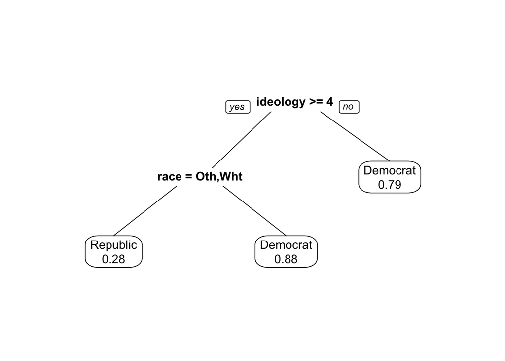

```r
cart_mod <- decision_tree() %>%
  set_engine("rpart", model = TRUE) %>%
  set_mode("classification")

cart_fit <- fit(cart_mod,
                    vote ~ ideology + income + gender + race,
                    data = nes)

cart_fit$fit %>%
  prp(extra = 6)
```

# Scene 3

**Prompt:** Following [the approach](https://davidkane9.github.io/PPBDS/13-classification.html#random-forests) outlined in the *Primer*, use **tidymodels** to estimate a random forest model in which `vote` is the dependent variable and `ideology`, `income`, `gender`, and `race` are the independent variables.

Hint: In addition to the functions you used in Scenes 1 and 2, you may find `rand_forest()` to be helpful.

Print out and interpret the model.

How many trees did the forest use? Would we get better results if we used a different number of trees?

What is OOB error?

```r
rf_mod <- rand_forest() %>%
  set_engine("randomForest") %>%
  set_mode("classification")

rf_fit <- fit(rf_mod,
              vote ~ ideology + income + gender + race,
              data = nes)

rf_fit
```

```
## parsnip model object
##
## Fit time:  3.3s
##
## Call:
##  randomForest(x = as.data.frame(x), y = y)
##                Type of random forest: classification
##                      Number of trees: 500
## No. of variables tried at each split: 2
##
##         OOB estimate of  error rate: 25.34%
## Confusion matrix:
##            Republican Democrat class.error
## Republican       3283      454   0.1214878
## Democrat         1232     1684   0.4224966
```

# Scene 4

**Prompt:** We’ve explored three ways to model binary responses in this chapter. Compare the accuracy of predictions of `logistic` vs `cart` vs `forest` on our `nes` data. Here are the steps to follow:

1. Use the models we have already estimated.
2. Add columns of each model’s prediction on `nes` by using `mutate` on `nes`. You should use `predict` and feed it the saved model and `new_data = nes`. `pull()` the `.pred_class` from the prediction.
3. Create a tibble with the accuracy of the prediction columns of each model.
4. Is accuracy the metric to use? Would using sensitivity or specificity be more appropriate?

Note: Accuracy = (Actual 1 as 1 + Actual 0 as 0) / n Sensitivity = The proportion of actual 1s classified as 1 Specificity = The proportion of actual 0s classified as 0

```r
nes_preds <- nes %>%
  mutate(logistic = predict(logistic_fit, new_data = nes) %>% pull(.pred_class),
         cart = predict(cart_fit, new_data = nes) %>% pull(.pred_class),
         rf = predict(rf_fit, new_data = nes) %>% pull(.pred_class))

nes_preds %>%
  filter(! (cart == rf)) %>%
  select(gender, income, vote, logistic, cart, rf) %>%
  sample_n(5)
```

```
## # A tibble: 5 x 6
##   gender income vote       logistic cart       rf
##   <fct>   <int> <fct>      <fct>    <fct>      <fct>
## 1 female      3 Democrat   Democrat Republican Democrat
## 2 female      3 Democrat   Democrat Republican Democrat
## 3 male        2 Republican Democrat Republican Democrat
## 4 female      3 Republican Democrat Republican Democrat
## 5 male        3 Democrat   Democrat Republican Democrat
```

```r
tibble(logistic = mean(nes_preds$logistic == nes_preds$vote),
       tree = mean(nes_preds$cart == nes_preds$vote),
       forest = mean(nes_preds$rf == nes_preds$vote))
```

```
## # A tibble: 1 x 3
##   logistic  tree forest
##      <dbl> <dbl>  <dbl>
## 1    0.745 0.743  0.749
```

# Challenge Problem

Make a cool animation with the nes data, using [this package](https://github.com/daranzolin/d3rain). Put the animation in an Rpubs page. Here are the animations which students in 1006 made yesterday (with different data):

https://rpubs.com/rmckenzie11/599663  
https://rpubs.com/evelyncai/d3rain_practice  
https://rpubs.com/diego_martinez/d3rain

Surely, you can make something better than what they did! You also have a much richer data set to play with than they had. Maybe separate panels for different years. Maybe voters rain down from different income or ideology categories across the top? There are many possibilities! Add a link with to [today’s Preceptor’s Notes](https://piazza.com/class/k5y1jx0s5ibe1?cid=721).